# Summary Statistics

For this lab, we will be looking at calculating summary statistics, such as a five-number-summary, as well as box plots.

We will be using the diamonds dataset from the openintro package. To view the data either run the code chunk below or type the command into your Console.

```r
View(diamonds)
```

##Five Number Summary

As you can see, this is a large data set with information on 53,940 individual diamonds! First lets calculate some summary statistics.

```r
summary(diamonds$price)
```

```
##    Min. 1st Qu.  Median    Mean 3rd Qu.    Max.
##     326     950    2401    3933    5324   18823
```

The summary() function outputs the five-number-summary, plus the mean, of a numeric variable.

Let’s see what happens when we use the summary() function on a categorical variable.

```r
summary(diamonds$color)
```

```
##     D     E     F     G     H     I     J
##  6775  9797  9542 11292  8304  5422  2808
```

With a categorical variable, summary() outputs a frequency distribution!

##Problem One: Calculate the five-number-summary for the carat and cut variables.

```r
#ENTER YOUR CODE HERE
```

##Challenge: Can you write one or two lines of code and calculate the summary statistics for ALL variables in the dataset?

```r
#ENTER YOUR CODE HERE
```

With such a large data set, it might be useful to have some summary statistics for specific subsets. For example, we might expect diamonds with different clarity to have different prices. The Tidyverse allows us to group our dataset by a specific variable before calculating summary values. For this, we’ll use the fivenum() function. For example:

```r
fivenum(diamonds$price)[1]
```

```
## [1] 326
```

Will give the minimum value (1st number of the summary) of the variable.

```r
diamonds_summary <- diamonds %>% #This will create a new data set called diamonds_summary by taking the diamonds dataset "and then"...
  group_by(clarity) %>%
  summarize(min = fivenum(price)[1],
            q1 = fivenum(price)[2],
            med = fivenum(price)[3],
            q3 = fivenum(price)[4],
            max = fivenum(price)[5])
```

##Problem Two: Calculate the five number summary for the different cuts.

```r
#INSERT YOUR CODE HERE
```

##Boxplots Let’s create a few boxplots.

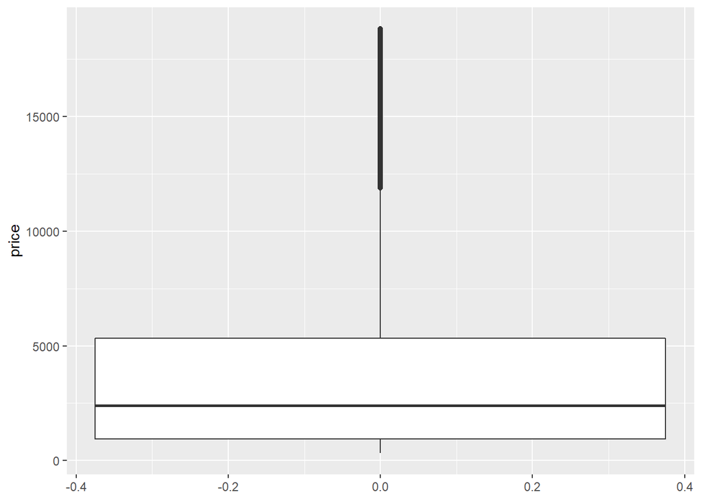

```r
ggplot(data = diamonds,
       aes(y = price))+
  geom_boxplot()
```

##Problem Three: Sketch a boxplot of the carat variable.

```r
#ENTER YOUR CODE HERE
```

What if we wanted the boxplot for the grouped data?

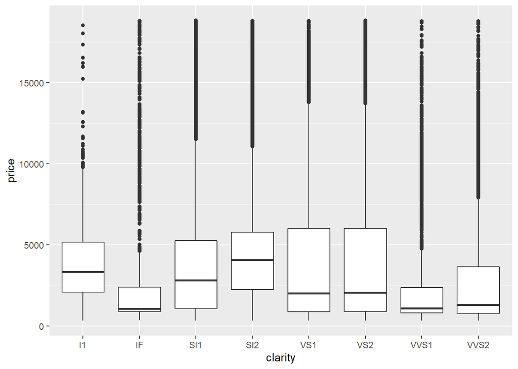

```r
ggplot(data = diamonds,
       aes(x = clarity,
           y = price))+
  geom_boxplot()
```

##Problem Four: Sketch a boxplot for the price of the diamonds when grouped by cut.

```r
#ENTER YOUR CODE HERE
```